# A07- ggplot

## Question 4: How Far?

Our goal is to find the distance between each pair of stations. You know the position from the lat and long variables in `Stations`. This is enough information to find the distance. The calculation has been implemented in the `haversine()` function. We can import the `haversine()` function using the following command.

```r
source("https://mdbeckman.github.io/dcSupplement/R/haversine.R")
```

`haversine()` is a transformation function. To use it, create a data table where a case is a pair of stations and there are variables for the latitude and longitude of the starting station and the ending station. To do this, join the Station data to itself. The following statements show how to create appropriately named variables for joining.

```r
Simple <-
  Stations %>%
  select(name, lat, long) %>%
  rename(sstation = name)

Simple2 <-
  Simple %>%
  rename(estation = sstation, lat2 = lat, long2 = long)
```

Look at the `head()` of `Simple` and `Simple2` and make sure you understand how they are related to `Stations.`

The joining of `Simple` and `Simple2` should match every station to every other station. Since a ride can start and end at the same station, it also makes sense to match each station to itself. This sort of matching does not make use of any matching variables; everything is matched to everything else. This is called a **full outer join**. See Lecture L09 to read more about joins. Note, we can also use the `merge()` function for full outer joins. See the help file for more details.

We perform the full outer join and then use `haversine()` to compute the distance between each pair of stations.

```r
#full outer join
StationPairs <- merge(Simple, Simple2, by = NULL)

#calculating distances
PairDistances <-
  StationPairs %>%
  mutate(distance = haversine(lat, long, lat2, long2)) %>%
  select(sstation, estation, distance)
```

Once you have `PairDistances`, you can join it with `Trips` to calculate the start-to-end distance of each trip. An `inner_join()` is appropriate for finding the distance of each ride.

Display the distribution of the ride distances of the rides. Compare it to the distances between pairs of stations. Are they similar? Why or why not?

Our goal here is to recreate [Figure 18.5](https://dtkaplan.github.io/DataComputingEbook/project-bicycle-sharing.html#fig:bike-hour-count). For this assignment, it is sufficient to make each density on its own plot. There is 1 point of extra credit if you can make the two densities on the same plot.

```r
StationPairs <- merge(Simple, Simple2, by = NULL)
```

```r
PairDistances <- StationPairs %>%
  mutate(distance = haversine(lat, long, lat2, long2)) %>%
  select(sstation, estation, distance)
```

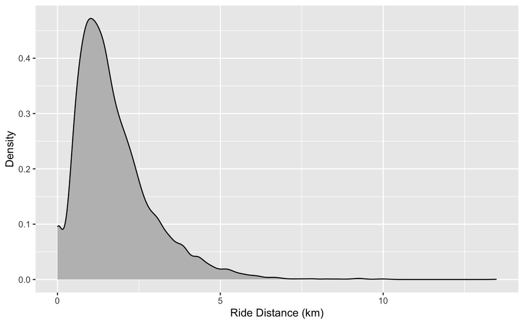

```r
TripsWithDistances <- inner_join(Trips, PairDistances, by = c("sstation", "estation"))
ggplot(TripsWithDistances, aes(x = distance)) +
  geom_density(fill = "gray", color = "black") +
  labs(x = "Ride Distance (km)", y = "Density")
```

```r
answer <- "They are similar because they have kind of a shape similarity i.e as distance inccreaces the density goes to a peak and then decreases to the lowest value. But the similarity os not too high hence there might be other facts beyond station distances that may influence ride distances."
cat(extra_credit)
```

[output not shown]

[output not shown]

[output not shown]

#### Extra Credit: Joining and Variable Names in R

Look at the variables in `Stations` and `Trips` and explain why `Simple` and `Simple2` were given different variable names for the station.

```r
extra_credit <- "Different variable names were given to Simple and Simple2 for the station so that it would be clear which station was the starting station and which was the finishing station when the join operation was run.

The variable in the Stations collection that stands for the name of the station is called name. But when you join the dataset to itself to make the pairs of stations, you need to include both the starting and finishing stations. In Simple, the variable name for the starting station is sstation, and in Simple2, the variable name for the finishing station is estation. This is done to avoid confusion and make the final dataset clear.

By giving each variable a unique name, it's easier to find and refer to the right stations during the join process and any calculations that follow. This naming practice helps keep the dataset clear and avoid any confusion.
"
cat(extra_credit)
```

[output not shown]